# Final Project: The Analysis of Hyperlocal Temperature Monitoring Data

- Group Member: “Chenxi Dong”, “Reece Hoff”, “Yuzhen Zhou”

## Introduction to Project

New York City is one of the largest cities in the US and experiences some of the most unpredictable weather. Whether that be intense snowstorms or even hurricanes. New York City has extremely similar weather to Madison due to its latitude position. Summer weather is often extremely important to people because people love to spend time outdoors and this requires desirable weather more specifically desirable temperatures. Analysis of NYC summer temperatures will help us determine the areas in New York that have the most desirable summer temperatures. It may be helpful to examine if the different boroughs in NY have different average max temepratures in the summer. Our question of interest was trying to determine if there are temperature differences between the boroughs despite their close geographical location.  
**Thesis**: This report will look at New York City temperature data from different boroughs and will provide analysis of this data. In addition this analysis will provide evidence that there is at least on average highest temperature difference between one borough and the others. We believe that there are some differences between the highest temperatures in the different boroughs despite their close geographical location

### Project Background

Weather is one of the most highly studied topics in the world. Since weather is highly studied there is a plethora of data about weather published online. Data about weather is typically collected based on geographic location. For example the dataset we have selected is data about the weather in New York City and the boroughs(unique neighborhoods) within NYC. A common measurement of weather that is used globally is temperature. Temperature is a measure of how hot or cold the air in the area is. Temperature in many areas often fluctuated with the season where we see cooler (lower) temperatures in the fall and winter and warmer(higher) temperatures in the summer and spring.

### Variables

day_maxtemp: the max temperature detected in a single day.

day_mintemp: the min temperature detected in a single day.

day_avgtemp: the mean temperature detected in a single day.

avg_maxtemp: average max temperature of a month.

avg_mintemp: average min temperature of a month.

sd_maxtemp: standard deviation of max temperature of a month.

sd_mintemp: standard deviation of max temperature of a month.

avg_avgtemp: average temperature of daily mean temperature in a month.

sample_size: number of days in a month that have temperature data.

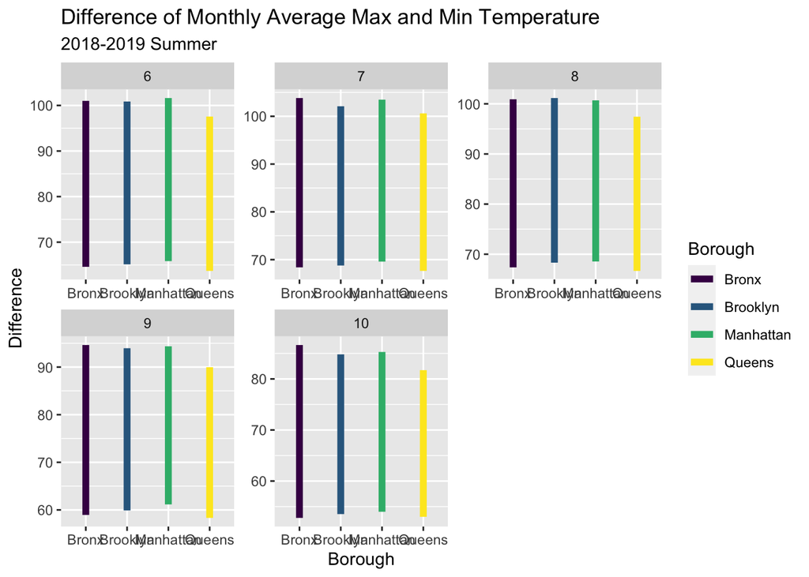

### Questions

#### The estimated highest temperature in summer and early fall for the four boroughs?

```
## # A tibble: 4 x 5
##   Borough   mu_day_highest sd_day_highest lower_ci upper_ci
##   <fct>              <dbl>          <dbl>    <dbl>    <dbl>
## 1 Bronx               98.4           7.82     114.     83.1
## 2 Brooklyn            97.6           7.91     113.     82.1
## 3 Manhattan           98.1           8.42     115.     81.6
## 4 Queens              94.5           7.96     110.     78.9
```

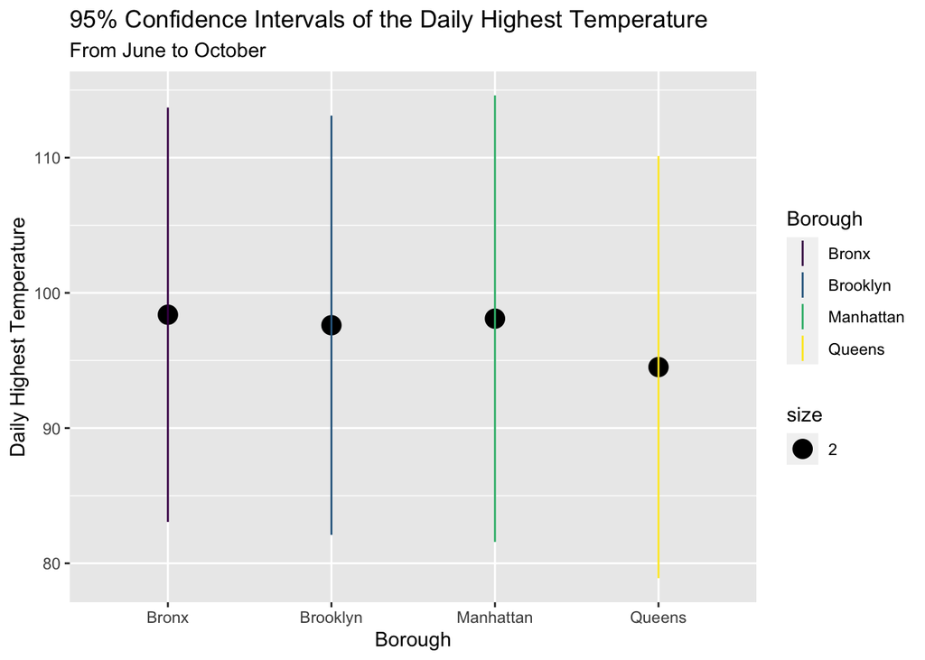

#### What is observed difference of Queens’ and the other three boroughs’ average highest temperature in summer and early fall?

- The observed difference of the highest temperature in summer and early fall between Queens and other three boroughs is 3.516241 degree Fahrenheit.

#### Assume there isn’t difference of the average highest temperature in summer and early fall between Queens and other three boroughs. Here are our hypothesis:

- $H_0: \mu_{\text{Queens}} = \mu_{\text{Others}}$
- $H_a: \mu_{\text{Queens}} \not= \mu_{\text{Others}}$

#### Does the observed bserved difference of Queens’ and the other three boroughs’ highest temperature significant with 95% confidence level?

- The p-value under the null hypothesis is 2.32928e-05, is less than 0.05, so we reject the null hypothesis

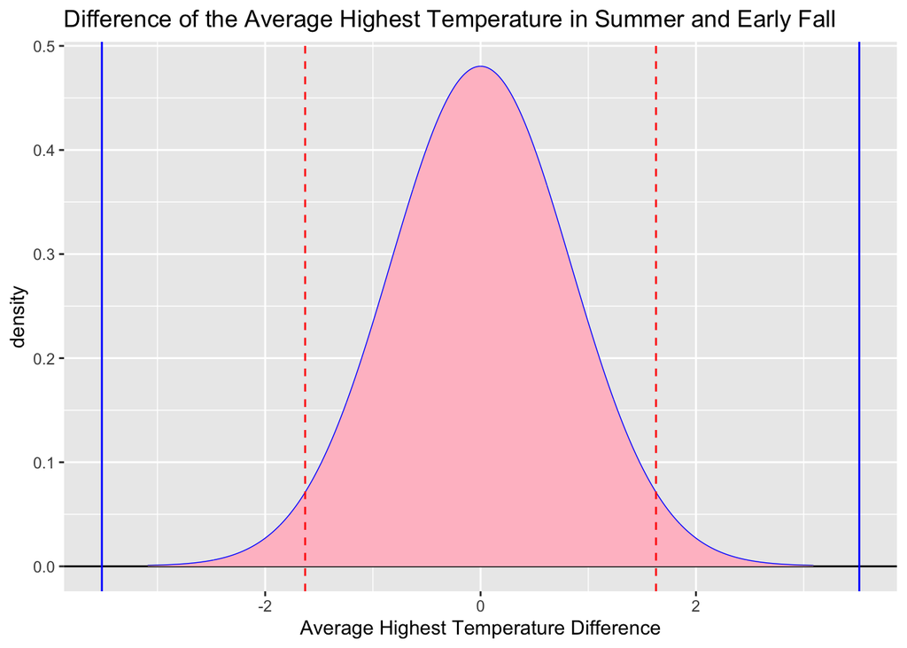

- The graph is constructed under the null hypothesis. And in this graph, the area between two red dashed lines is the 95% confidence interval, the areas that outside two solid blue lines represent the p_value.

## Discussion

We rejected the null in our hypothesis test therefore the average highest temperature in summer and early fall between Queens and other three boroughs is not the same. This helps support our hypothesis by showing that although only Queens shows a average highest temperature difference there is a difference.  
A potential short coming of our analysis is we only have data from 5 months of the year therefore our data is limited to the summer and early fall months so our analysis was limited to only analyzing the temperature in those months. A way to solve this short coming is to collect more data over a longer period of time.  
A future direction for this analysis is we could do similar analysis for different cities across the such as San Francisco. Another direction we could go using this data is examine if the type of sensor affected the temperature reading or if a certain type of sensor consistently read significantly higher or lower temperatures.Additionally it may he helpful to collect rainfall data about the different boroughs and we can perform similar analysis to what we did in this project.

In conclusion in our analysis we saw that the Queens borough has a different average highest temperatrure in the years from 2018-2019 than the other boroughs in New York. This is supported rejecting the null hypothesus in the hypothesis test we performed (see above).

[^1]

[^1]: Hyperlocal Temperature Monitoring: https://data.cityofnewyork.us/dataset/Hyperlocal-Temperature-Monitoring/qdq3-9eqn